# TÜİK Forecasting Project: Monthly Births in Turkey

Ömer Faruk Dönmez

2026-06-02

# 1 Project Overview

This project forecasts the **total number of monthly births in Turkey** using data obtained directly from the TÜİK Data Portal via the `tuikr` R package.

- **TÜİK Theme:** Population and Demography (Theme 11)
- **Table Name:** Births by sex and month, 2001-2025
- **Selected Variable:** Total monthly births (Toplam-Total)
- **Data Frequency:** Monthly
- **Time Coverage:** January 2001 - December 2025
- **Latest Available Observation:** December 2025
- **Forecast Target Period:** January 2026
- **Data Access Date:** 2026-06-02

# 2 Data Access via tuikr

```r
# Access TÜİK Population and Demography theme tables via tuikr
tema11 <- statistical_tables("11")

# Filter istab type tables
istab11 <- tema11[tema11$node_type == "istab", ]

# Filter tables with birth and month information
istab11_aylik <- istab11[grepl("month|birth|Month|Birth",
                                istab11$table_name, ignore.case = TRUE), ]

# Select "Births by sex and month" table (row 83)
selected_url <- istab11_aylik$table_url[83]

cat("Selected table:", istab11_aylik$table_name[83], "\n")
```

```
## Selected table: Births by sex and month
```

```r
cat("Access method: istab URL via tuikr::statistical_tables('11')\n")
```

```
## Access method: istab URL via tuikr::statistical_tables('11')
```

```r
cat("Data access date:", as.character(Sys.Date()), "\n")
```

```
## Data access date: 2026-06-02
```

```r
# Download data using httr with session cookie
session <- GET("https://veriportali.tuik.gov.tr/en/statistical-themes",
               add_headers("User-Agent" = "Mozilla/5.0"))

tmp <- tempfile(fileext = ".xls")
resp <- GET(selected_url,
            add_headers(
              "User-Agent" = "Mozilla/5.0 (Windows NT 10.0; Win64; x64)",
              "Referer" = "https://veriportali.tuik.gov.tr/en/statistical-themes"
            ),
            write_disk(tmp, overwrite = TRUE))

cat("HTTP Status:", status_code(resp), "\n")
```

```
## HTTP Status: 200
```

```r
cat("File size:", file.size(tmp), "bytes\n")
```

```
## File size: 50176 bytes
```

```r
# Read the downloaded xls file
df_raw <- read_xls(tmp)
cat("Raw data dimensions:", nrow(df_raw), "rows x", ncol(df_raw), "cols\n")
```

```
## Raw data dimensions: 84 rows x 15 cols
```

# 3 Data Cleaning and Preparation

```r
# Rename columns
colnames(df_raw) <- c("year", "sex", "total", "Jan", "Feb", "Mar", "Apr", "May",
                       "Jun", "Jul", "Aug", "Sep", "Oct", "Nov", "Dec")

# Fill down year column (merged cells in original Excel)
df_raw <- df_raw %>% fill(year, .direction = "down")

# Keep only Total rows, remove header rows
df_total <- df_raw %>%
  filter(sex == "Toplam-Total") %>%
  filter(!is.na(Jan))

# Convert from wide to long format
df_long <- df_total %>%
  select(year, Jan:Dec) %>%
  pivot_longer(cols = Jan:Dec, names_to = "month", values_to = "births") %>%
  mutate(
    year      = as.integer(substr(year, 1, 4)),
    births    = as.numeric(births),
    month_num = match(month, c("Jan","Feb","Mar","Apr","May","Jun",
                                "Jul","Aug","Sep","Oct","Nov","Dec")),
    date      = as.Date(paste(year, month_num, "01", sep = "-"))
  ) %>%
  arrange(date) %>%
  filter(!is.na(births))

# Add time index
df_long$t_index <- 1:nrow(df_long)

# Summary
cat("Total observations:", nrow(df_long), "\n")
```

```
## Total observations: 300
```

```r
cat("First observation:", as.character(min(df_long$date)), "\n")
```

```
## First observation: 2001-01-01
```

```r
cat("Latest observation:", as.character(max(df_long$date)), "\n")
```

```
## Latest observation: 2025-12-01
```

```r
cat("Forecast target: January 2026\n")
```

```
## Forecast target: January 2026
```

```r
cat("Missing values:", sum(is.na(df_long$births)), "\n")
```

```
## Missing values: 0
```

```r
head(df_long[, c("date", "births")], 6)
```

```
## # A tibble: 6 × 2
##   date       births
##   <date>      <dbl>
## 1 2001-01-01 170397
## 2 2001-02-01 103476
## 3 2001-03-01 107912
## 4 2001-04-01 102585
## 5 2001-05-01 110391
## 6 2001-06-01 111722
```

# 4 Exploratory Time Series Analysis

```r
# Create time series object
ts_births <- ts(df_long$births, start = c(2001, 1), frequency = 12)

cat("Mean:", round(mean(df_long$births)), "\n")
```

```
## Mean: 100775
```

```r
cat("Min:", min(df_long$births),
    "—", format(df_long$date[which.min(df_long$births)], "%Y-%m"), "\n")
```

```
## Min: 65208 — 2025-02
```

```r
cat("Max:", max(df_long$births),
    "—", format(df_long$date[which.max(df_long$births)], "%Y-%m"), "\n")
```

```
## Max: 170397 — 2001-01
```

```r
cat("Std Dev:", round(sd(df_long$births)), "\n")
```

```
## Std Dev: 15384
```

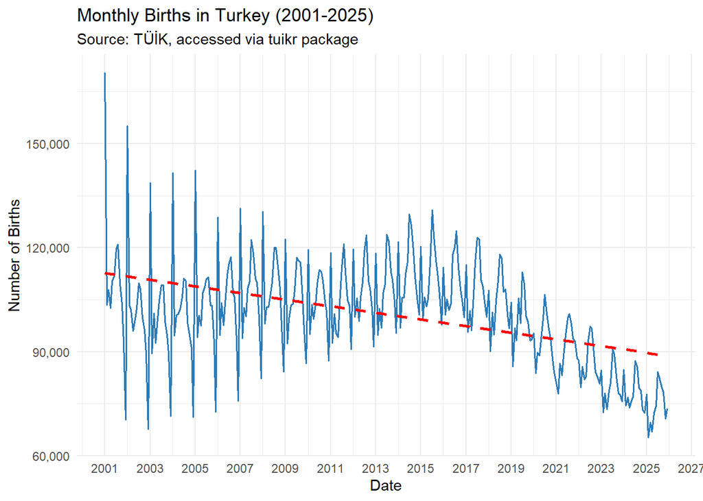

Actual Monthly Births in Turkey (2001-2025)

```r
ggplot(df_long, aes(x = date, y = births)) +
  geom_line(color = "#2C7BB6", linewidth = 0.7) +
  geom_smooth(method = "lm", color = "red", linetype = "dashed", se = FALSE) +
  labs(
    title    = "Monthly Births in Turkey (2001-2025)",
    subtitle = "Source: TÜİK, accessed via tuikr package",
    x = "Date", y = "Number of Births"
  ) +
  theme_minimal() +
  scale_y_continuous(labels = scales::comma) +
  scale_x_date(date_breaks = "2 years", date_labels = "%Y")
```

```r
ggsave("outputs/figures/actual_series_plot.png", width = 10, height = 5, dpi = 150)
```

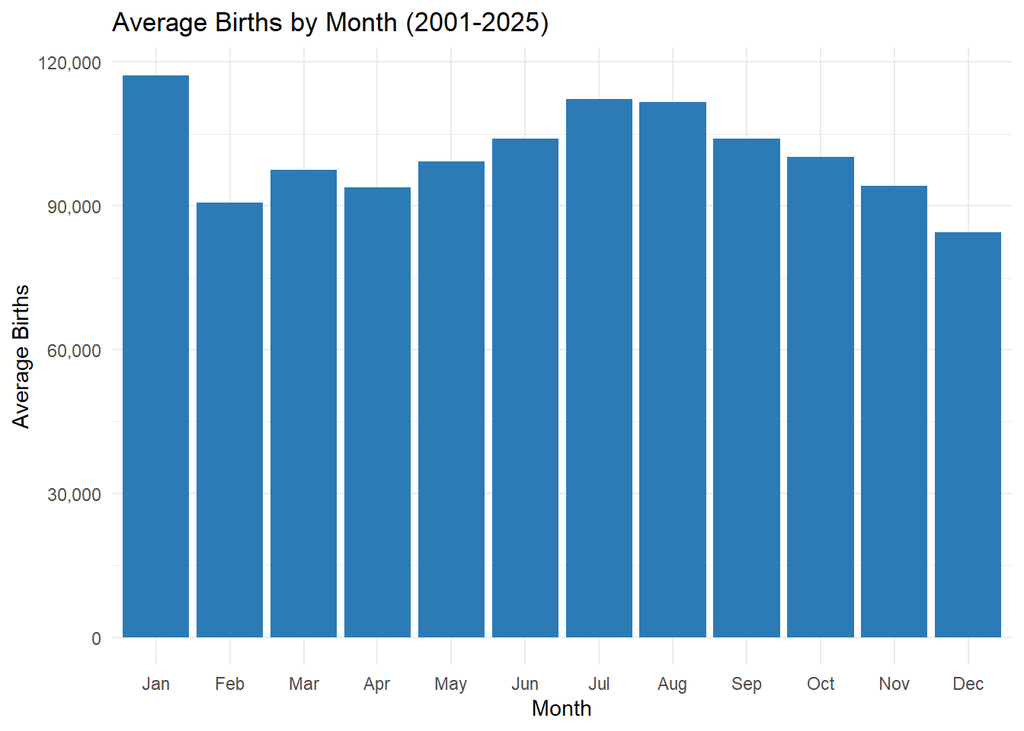

```r
monthly_avg <- df_long %>%
  group_by(month_num, month) %>%
  summarise(avg_births = mean(births), .groups = "drop") %>%
  arrange(month_num)

ggplot(monthly_avg, aes(x = factor(month_num, labels = month.abb), y = avg_births)) +
  geom_bar(stat = "identity", fill = "#2C7BB6") +
  labs(title = "Average Births by Month (2001-2025)",
       x = "Month", y = "Average Births") +
  theme_minimal() +
  scale_y_continuous(labels = scales::comma)
```

# 5 Forecast Accuracy Function

```r
# Function to calculate all required accuracy measures
calc_accuracy <- function(actual, forecast) {
  errors <- actual - forecast
  bias   <- mean(errors)
  mad    <- mean(abs(errors))
  mse    <- mean(errors^2)
  mape   <- mean(abs(errors / actual)) * 100
  rsfe   <- sum(errors)
  ts_val <- rsfe / mad
  list(Bias = round(bias, 2), MAD = round(mad, 2), MSE = round(mse, 2),
       MAPE = round(mape, 4), RSFE = round(rsfe, 2),
       Tracking_Signal = round(ts_val, 4))
}
```

# 6 Forecasting Methods

## 6.1 Naive Forecasting

```r
df_long$naive <- c(NA, df_long$births[-nrow(df_long)])

acc_naive  <- calc_accuracy(df_long$births[!is.na(df_long$naive)],
                             df_long$naive[!is.na(df_long$naive)])
naive_next <- tail(df_long$births, 1)

cat("Naive forecast (Jan 2026):", round(naive_next), "\n")
```

```
## Naive forecast (Jan 2026): 73534
```

```r
cat("Bias:", acc_naive$Bias, "| MAD:", acc_naive$MAD, "| MAPE:", acc_naive$MAPE, "%\n")
```

```
## Bias: -323.96 | MAD: 9656.53 | MAPE: 9.4105 %
```

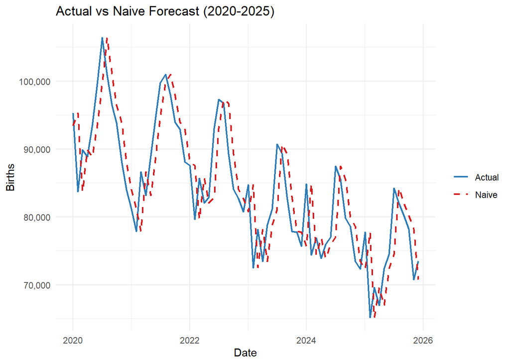

```r
ggplot(df_long %>% filter(date >= "2020-01-01"), aes(x = date)) +
  geom_line(aes(y = births, color = "Actual"), linewidth = 0.8) +
  geom_line(aes(y = naive,  color = "Naive"), linewidth = 0.8, linetype = "dashed") +
  scale_color_manual(values = c("Actual" = "#2C7BB6", "Naive" = "#D7191C")) +
  labs(title = "Actual vs Naive Forecast (2020-2025)",
       x = "Date", y = "Births", color = "") +
  theme_minimal() + scale_y_continuous(labels = scales::comma)
```

```r
ggsave("outputs/figures/naive_forecast_plot.png", width = 10, height = 5, dpi = 150)
```

## 6.2 Moving Average

```r
# 12-month window captures one full seasonal cycle
window <- 12
ma_vals <- stats::filter(df_long$births, rep(1/window, window), sides = 1)
df_long$ma12 <- c(rep(NA, window), as.numeric(ma_vals)[1:(length(ma_vals) - window)])

acc_ma  <- calc_accuracy(df_long$births[!is.na(df_long$ma12)],
                          df_long$ma12[!is.na(df_long$ma12)])
ma_next <- mean(tail(df_long$births, 12))

cat("Moving Average (12) forecast (Jan 2026):", round(ma_next), "\n")
```

```
## Moving Average (12) forecast (Jan 2026): 74614
```

```r
cat("Bias:", acc_ma$Bias, "| MAD:", acc_ma$MAD, "| MAPE:", acc_ma$MAPE, "%\n")
```

```
## Bias: -1830.09 | MAD: 8750.67 | MAPE: 9.0459 %
```

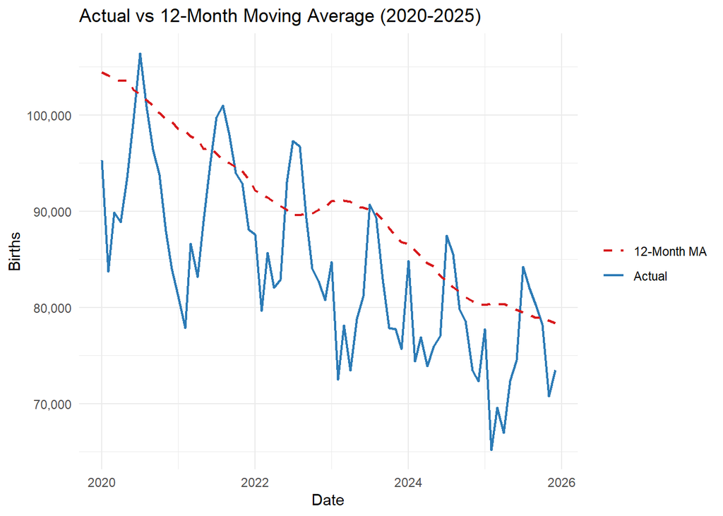

```r
ggplot(df_long %>% filter(date >= "2020-01-01"), aes(x = date)) +
  geom_line(aes(y = births, color = "Actual"), linewidth = 0.8) +
  geom_line(aes(y = ma12,   color = "12-Month MA"), linewidth = 0.8, linetype = "dashed") +
  scale_color_manual(values = c("Actual" = "#2C7BB6", "12-Month MA" = "#D7191C")) +
  labs(title = "Actual vs 12-Month Moving Average (2020-2025)",
       x = "Date", y = "Births", color = "") +
  theme_minimal() + scale_y_continuous(labels = scales::comma)
```

```r
ggsave("outputs/figures/moving_average_plot.png", width = 10, height = 5, dpi = 150)
```

## 6.3 Weighted Moving Average

```r
# Weights: 0.5 (most recent), 0.3, 0.2 — emphasise recent observations
w <- c(0.5, 0.3, 0.2)
wma_vals <- rep(NA, nrow(df_long))
for (i in 4:nrow(df_long)) {
  wma_vals[i] <- w[1]*df_long$births[i-1] + w[2]*df_long$births[i-2] + w[3]*df_long$births[i-3]
}
df_long$wma <- wma_vals

acc_wma  <- calc_accuracy(df_long$births[!is.na(df_long$wma)],
                           df_long$wma[!is.na(df_long$wma)])
wma_next <- w[1]*df_long$births[nrow(df_long)] +
            w[2]*df_long$births[nrow(df_long)-1] +
            w[3]*df_long$births[nrow(df_long)-2]

cat("WMA forecast (Jan 2026):", round(wma_next), "\n")
```

```
## WMA forecast (Jan 2026): 73638
```

```r
cat("Bias:", acc_wma$Bias, "| MAD:", acc_wma$MAD, "| MAPE:", acc_wma$MAPE, "%\n")
```

```
## Bias: -232.9 | MAD: 9095.99 | MAPE: 8.9113 %
```

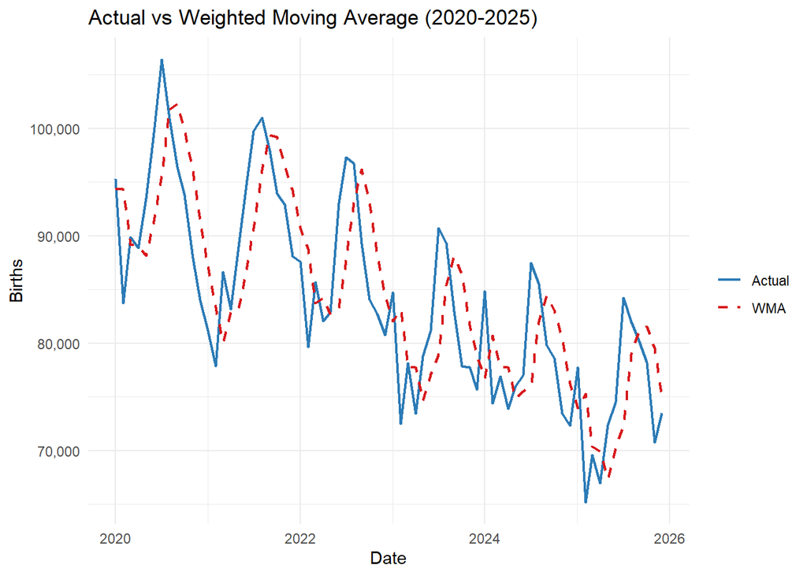

```r
ggplot(df_long %>% filter(date >= "2020-01-01"), aes(x = date)) +
  geom_line(aes(y = births, color = "Actual"), linewidth = 0.8) +
  geom_line(aes(y = wma,    color = "WMA"), linewidth = 0.8, linetype = "dashed") +
  scale_color_manual(values = c("Actual" = "#2C7BB6", "WMA" = "#D7191C")) +
  labs(title = "Actual vs Weighted Moving Average (2020-2025)",
       x = "Date", y = "Births", color = "") +
  theme_minimal() + scale_y_continuous(labels = scales::comma)
```

```r
ggsave("outputs/figures/weighted_moving_average_plot.png", width = 10, height = 5, dpi = 150)
```

## 6.4 Exponential Smoothing

```r
# alpha = 0.3: gradual adjustment, suitable for smooth trend
alpha  <- 0.3
es_vals    <- rep(NA, nrow(df_long))
es_vals[1] <- df_long$births[1]
for (i in 2:nrow(df_long)) {
  es_vals[i] <- alpha * df_long$births[i-1] + (1 - alpha) * es_vals[i-1]
}
df_long$es <- es_vals

acc_es  <- calc_accuracy(df_long$births[2:nrow(df_long)],
                          df_long$es[2:nrow(df_long)])
es_next <- alpha * df_long$births[nrow(df_long)] + (1 - alpha) * df_long$es[nrow(df_long)]

cat("Exponential Smoothing (alpha=0.3) forecast (Jan 2026):", round(es_next), "\n")
```

```
## Exponential Smoothing (alpha=0.3) forecast (Jan 2026): 75316
```

```r
cat("Bias:", acc_es$Bias, "| MAD:", acc_es$MAD, "| MAPE:", acc_es$MAPE, "%\n")
```

```
## Bias: -1059.99 | MAD: 9087.62 | MAPE: 9.0327 %
```

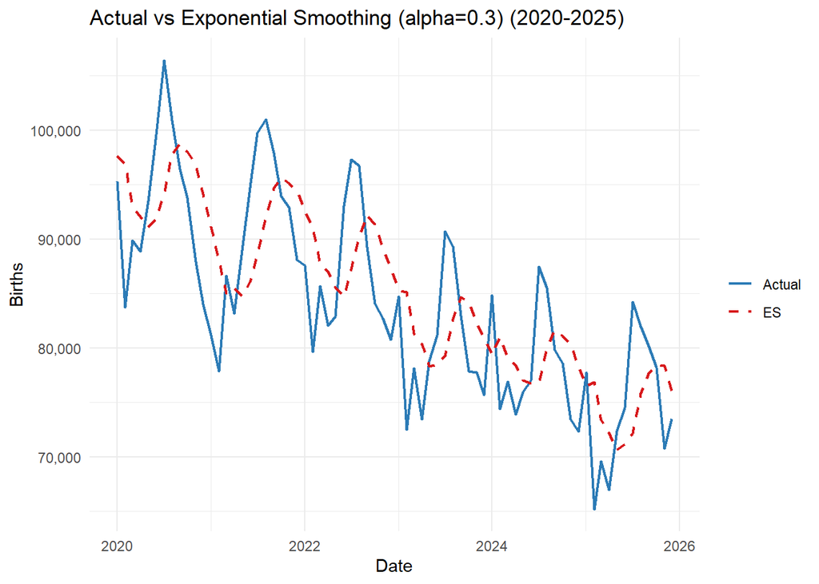

```r
ggplot(df_long %>% filter(date >= "2020-01-01"), aes(x = date)) +
  geom_line(aes(y = births, color = "Actual"), linewidth = 0.8) +
  geom_line(aes(y = es,     color = "ES"), linewidth = 0.8, linetype = "dashed") +
  scale_color_manual(values = c("Actual" = "#2C7BB6", "ES" = "#D7191C")) +
  labs(title = "Actual vs Exponential Smoothing (alpha=0.3) (2020-2025)",
       x = "Date", y = "Births", color = "") +
  theme_minimal() + scale_y_continuous(labels = scales::comma)
```

```r
ggsave("outputs/figures/exponential_smoothing_plot.png", width = 10, height = 5, dpi = 150)
```

## 6.5 Trend-Adjusted Exponential Smoothing

```r
# Series shows clear downward trend — TAES is applicable
alpha_t <- 0.3; beta_t <- 0.1
level_t <- df_long$births[1]
trend_t <- df_long$births[2] - df_long$births[1]
taes_vals    <- rep(NA, nrow(df_long))
taes_vals[1] <- level_t + trend_t

for (i in 2:nrow(df_long)) {
  prev_level <- level_t
  level_t    <- alpha_t * df_long$births[i] + (1 - alpha_t) * (level_t + trend_t)
  trend_t    <- beta_t  * (level_t - prev_level) + (1 - beta_t) * trend_t
  taes_vals[i] <- level_t + trend_t
}
df_long$taes <- taes_vals

acc_taes  <- calc_accuracy(df_long$births[2:nrow(df_long)],
                            df_long$taes[2:nrow(df_long)])
taes_next <- level_t + trend_t

cat("Trend-Adjusted ES forecast (Jan 2026):", round(taes_next), "\n")
```

```
## Trend-Adjusted ES forecast (Jan 2026): 75160
```

```r
cat("Bias:", acc_taes$Bias, "| MAD:", acc_taes$MAD, "| MAPE:", acc_taes$MAPE, "%\n")
```

```
## Bias: 7545.62 | MAD: 12675.29 | MAPE: 12.1413 %
```

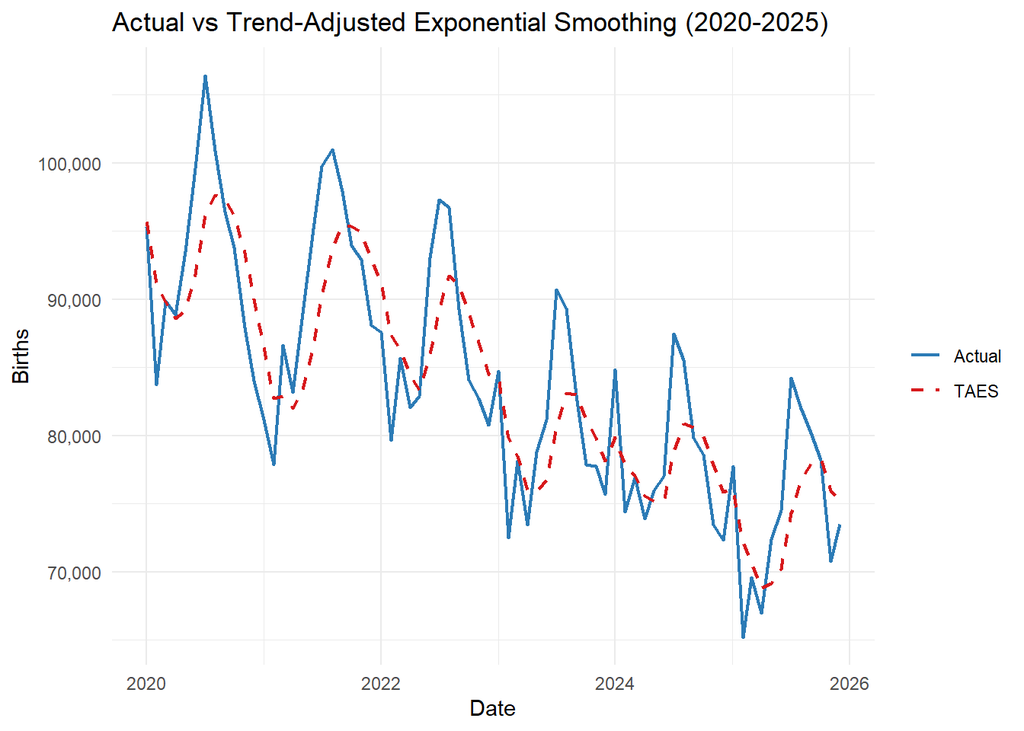

```r
ggplot(df_long %>% filter(date >= "2020-01-01"), aes(x = date)) +
  geom_line(aes(y = births, color = "Actual"), linewidth = 0.8) +
  geom_line(aes(y = taes,   color = "TAES"), linewidth = 0.8, linetype = "dashed") +
  scale_color_manual(values = c("Actual" = "#2C7BB6", "TAES" = "#D7191C")) +
  labs(title = "Actual vs Trend-Adjusted Exponential Smoothing (2020-2025)",
       x = "Date", y = "Births", color = "") +
  theme_minimal() + scale_y_continuous(labels = scales::comma)
```

```r
ggsave("outputs/figures/trend_adjusted_smoothing_plot.png", width = 10, height = 5, dpi = 150)
```

## 6.6 Linear Trend Projection

```r
lm_model      <- lm(births ~ t_index, data = df_long)
df_long$lm_fit <- fitted(lm_model)

cat("Intercept:", round(coef(lm_model)[1]), "— estimated births at t=0\n")
```

```
## Intercept: 112810 — estimated births at t=0
```

```r
cat("Slope:", round(coef(lm_model)[2], 2), "— monthly change in births\n")
```

```
## Slope: -79.97 — monthly change in births
```

```r
acc_lm  <- calc_accuracy(df_long$births, df_long$lm_fit)
lm_next <- predict(lm_model, newdata = data.frame(t_index = nrow(df_long) + 1))

cat("Linear Trend forecast (Jan 2026):", round(lm_next), "\n")
```

```
## Linear Trend forecast (Jan 2026): 88740
```

```r
cat("Bias:", acc_lm$Bias, "| MAD:", acc_lm$MAD, "| MAPE:", acc_lm$MAPE, "%\n")
```

```
## Bias: 0 | MAD: 10578.5 | MAPE: 10.7997 %
```

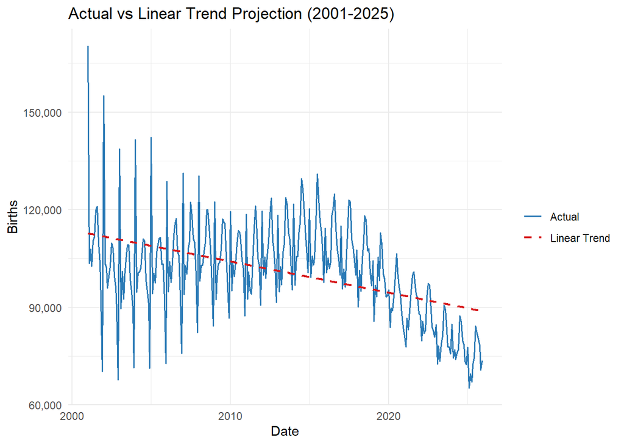

```r
ggplot(df_long, aes(x = date)) +
  geom_line(aes(y = births,  color = "Actual"), linewidth = 0.7) +
  geom_line(aes(y = lm_fit,  color = "Linear Trend"), linewidth = 0.8, linetype = "dashed") +
  scale_color_manual(values = c("Actual" = "#2C7BB6", "Linear Trend" = "#D7191C")) +
  labs(title = "Actual vs Linear Trend Projection (2001-2025)",
       x = "Date", y = "Births", color = "") +
  theme_minimal() + scale_y_continuous(labels = scales::comma)
```

```r
ggsave("outputs/figures/trend_projection_plot.png", width = 10, height = 5, dpi = 150)
```

## 6.7 Seasonal Indices

```r
# 12 seasons — ratio-to-moving-average method
ma12_centered <- stats::filter(df_long$births, rep(1/12, 12), sides = 2)
df_long$si_ratio <- df_long$births / ma12_centered
df_long$month_num2 <- as.numeric(format(df_long$date, "%m"))

si_table <- df_long %>%
  filter(!is.na(si_ratio)) %>%
  group_by(month_num2) %>%
  summarise(si = mean(si_ratio), .groups = "drop")

# Normalize
si_table$si <- si_table$si * (12 / sum(si_table$si))

cat("Seasonal Indices:\n")
```

```
## Seasonal Indices:
```

```r
print(data.frame(Month = month.abb, SI = round(si_table$si, 4)))
```

```
##    Month     SI
## 1    Jan 1.1373
## 2    Feb 0.8962
## 3    Mar 0.9655
## 4    Apr 0.9308
## 5    May 0.9845
## 6    Jun 1.0318
## 7    Jul 1.1171
## 8    Aug 1.1123
## 9    Sep 1.0366
## 10   Oct 0.9997
## 11   Nov 0.9427
## 12   Dec 0.8455
```

```r
# Deseasonalized series
df_long$deseason <- df_long$births / si_table$si[df_long$month_num2]

# Trend on deseasonalized
lm_deseas  <- lm(deseason ~ t_index, data = df_long)
si_fitted  <- fitted(lm_deseas) * si_table$si[df_long$month_num2]
df_long$si_fit <- si_fitted

acc_si  <- calc_accuracy(df_long$births, df_long$si_fit)

# Forecast Jan 2026
deseas_next <- predict(lm_deseas, newdata = data.frame(t_index = nrow(df_long) + 1))
si_next     <- deseas_next * si_table$si[1]   # January = month 1

cat("Seasonal Indices forecast (Jan 2026):", round(si_next), "\n")
```

```
## Seasonal Indices forecast (Jan 2026): 101547
```

```r
cat("Bias:", acc_si$Bias, "| MAD:", acc_si$MAD, "| MAPE:", acc_si$MAPE, "%\n")
```

```
## Bias: 24.78 | MAD: 7981.66 | MAPE: 8.2473 %
```

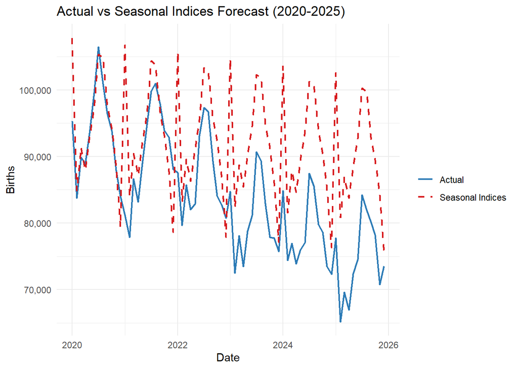

```r
ggplot(df_long %>% filter(date >= "2020-01-01"), aes(x = date)) +
  geom_line(aes(y = births, color = "Actual"), linewidth = 0.8) +
  geom_line(aes(y = si_fit, color = "Seasonal Indices"), linewidth = 0.8, linetype = "dashed") +
  scale_color_manual(values = c("Actual" = "#2C7BB6", "Seasonal Indices" = "#D7191C")) +
  labs(title = "Actual vs Seasonal Indices Forecast (2020-2025)",
       x = "Date", y = "Births", color = "") +
  theme_minimal() + scale_y_continuous(labels = scales::comma)
```

```r
ggsave("outputs/figures/seasonal_indices_plot.png", width = 10, height = 5, dpi = 150)
```

## 6.8 Additive Decomposition

```r
decomp_add <- decompose(ts_births, type = "additive")

trend_add    <- as.numeric(decomp_add$trend)
seasonal_add <- as.numeric(decomp_add$seasonal)
fitted_add   <- trend_add + seasonal_add

# Trend extrapolation
trend_add_clean <- trend_add[!is.na(trend_add)]
t_add           <- seq_along(trend_add_clean)
lm_add          <- lm(trend_add_clean ~ t_add)
trend_next_add  <- predict(lm_add, newdata = data.frame(t_add = length(trend_add_clean) + 1))
add_next        <- trend_next_add + seasonal_add[1]   # January seasonal

acc_add <- calc_accuracy(df_long$births[!is.na(fitted_add)],
                          fitted_add[!is.na(fitted_add)])

cat("Additive Decomposition forecast (Jan 2026):", round(add_next), "\n")
```

```
## Additive Decomposition forecast (Jan 2026): 104867
```

```r
cat("Bias:", acc_add$Bias, "| MAD:", acc_add$MAD, "| MAPE:", acc_add$MAPE, "%\n")
```

```
## Bias: -38.04 | MAD: 3714.12 | MAPE: 3.8058 %
```

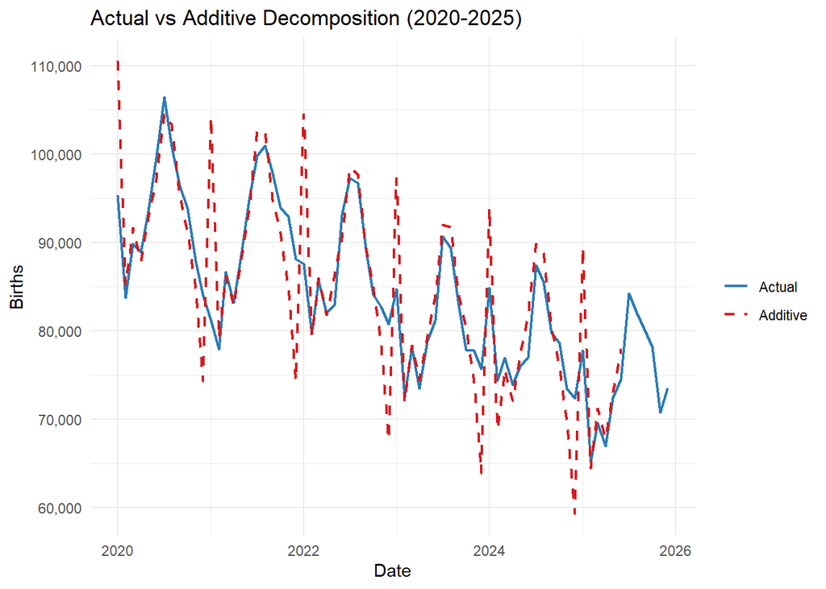

```r
df_add_plot <- data.frame(date = df_long$date, births = df_long$births,
                           fitted = fitted_add)

ggplot(df_add_plot %>% filter(date >= "2020-01-01"), aes(x = date)) +
  geom_line(aes(y = births, color = "Actual"), linewidth = 0.8) +
  geom_line(aes(y = fitted, color = "Additive"), linewidth = 0.8, linetype = "dashed") +
  scale_color_manual(values = c("Actual" = "#2C7BB6", "Additive" = "#D7191C")) +
  labs(title = "Actual vs Additive Decomposition (2020-2025)",
       x = "Date", y = "Births", color = "") +
  theme_minimal() + scale_y_continuous(labels = scales::comma)
```

```r
ggsave("outputs/figures/additive_decomposition_plot.png", width = 10, height = 5, dpi = 150)
```

## 6.9 Multiplicative Decomposition

```r
decomp_mult <- decompose(ts_births, type = "multiplicative")

trend_mult    <- as.numeric(decomp_mult$trend)
seasonal_mult <- as.numeric(decomp_mult$seasonal)
fitted_mult   <- trend_mult * seasonal_mult

# Trend extrapolation
trend_mult_clean <- trend_mult[!is.na(trend_mult)]
t_mult           <- seq_along(trend_mult_clean)
lm_mult          <- lm(trend_mult_clean ~ t_mult)
trend_next_mult  <- predict(lm_mult, newdata = data.frame(t_mult = length(trend_mult_clean) + 1))
mult_next        <- trend_next_mult * seasonal_mult[1]

acc_mult <- calc_accuracy(df_long$births[!is.na(fitted_mult)],
                           fitted_mult[!is.na(fitted_mult)])

cat("Multiplicative Decomposition forecast (Jan 2026):", round(mult_next), "\n")
```

```
## Multiplicative Decomposition forecast (Jan 2026): 103061
```

```r
cat("Bias:", acc_mult$Bias, "| MAD:", acc_mult$MAD, "| MAPE:", acc_mult$MAPE, "%\n")
```

```
## Bias: -54.3 | MAD: 3557.57 | MAPE: 3.6234 %
```

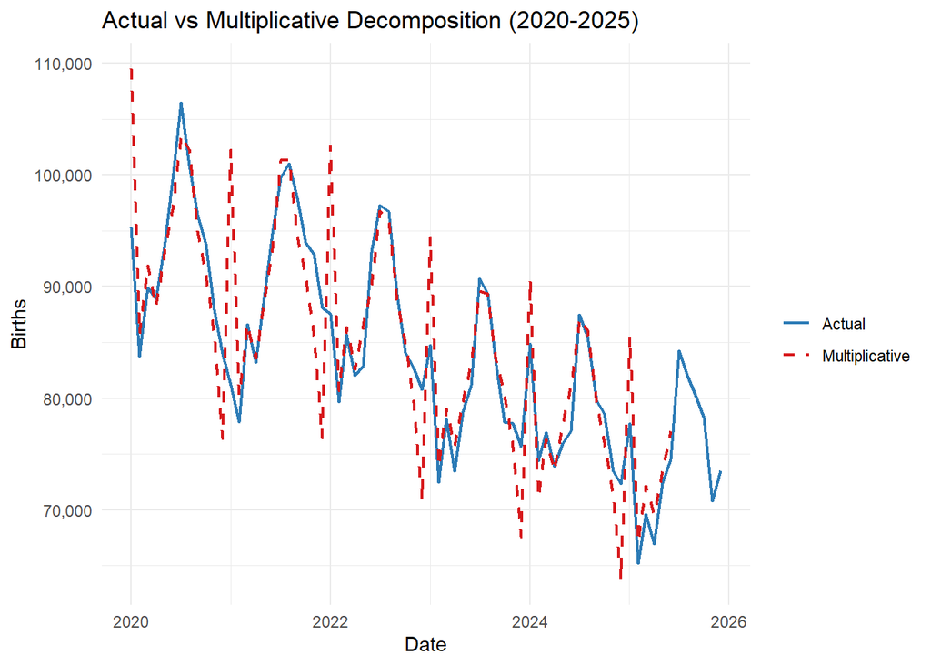

```r
df_mult_plot <- data.frame(date = df_long$date, births = df_long$births,
                            fitted = fitted_mult)

ggplot(df_mult_plot %>% filter(date >= "2020-01-01"), aes(x = date)) +
  geom_line(aes(y = births, color = "Actual"), linewidth = 0.8) +
  geom_line(aes(y = fitted, color = "Multiplicative"), linewidth = 0.8, linetype = "dashed") +
  scale_color_manual(values = c("Actual" = "#2C7BB6", "Multiplicative" = "#D7191C")) +
  labs(title = "Actual vs Multiplicative Decomposition (2020-2025)",
       x = "Date", y = "Births", color = "") +
  theme_minimal() + scale_y_continuous(labels = scales::comma)
```

```r
ggsave("outputs/figures/multiplicative_decomposition_plot.png", width = 10, height = 5, dpi = 150)
```

## 6.10 Regression with Trend and Seasonal Dummy Variables

```r
# Create seasonal dummy variables (January = base category)
df_long$month_factor <- factor(format(df_long$date, "%m"))
df_long$month_factor <- relevel(df_long$month_factor, ref = "01")

# Fit regression
lm_seasonal    <- lm(births ~ t_index + month_factor, data = df_long)
df_long$reg_fit <- fitted(lm_seasonal)

cat("Trend coefficient:", round(coef(lm_seasonal)["t_index"], 2),
    "— monthly change after controlling for seasonality\n")
```

```
## Trend coefficient: -78.89 — monthly change after controlling for seasonality
```

```r
acc_reg  <- calc_accuracy(df_long$births, df_long$reg_fit)
reg_next <- predict(lm_seasonal, newdata = data.frame(
  t_index      = nrow(df_long) + 1,
  month_factor = factor("01", levels = levels(df_long$month_factor))
))

cat("Regression with Dummies forecast (Jan 2026):", round(reg_next), "\n")
```

```
## Regression with Dummies forecast (Jan 2026): 104950
```

```r
cat("Bias:", acc_reg$Bias, "| MAD:", acc_reg$MAD, "| MAPE:", acc_reg$MAPE, "%\n")
```

```
## Bias: 0 | MAD: 8028.33 | MAPE: 8.3106 %
```

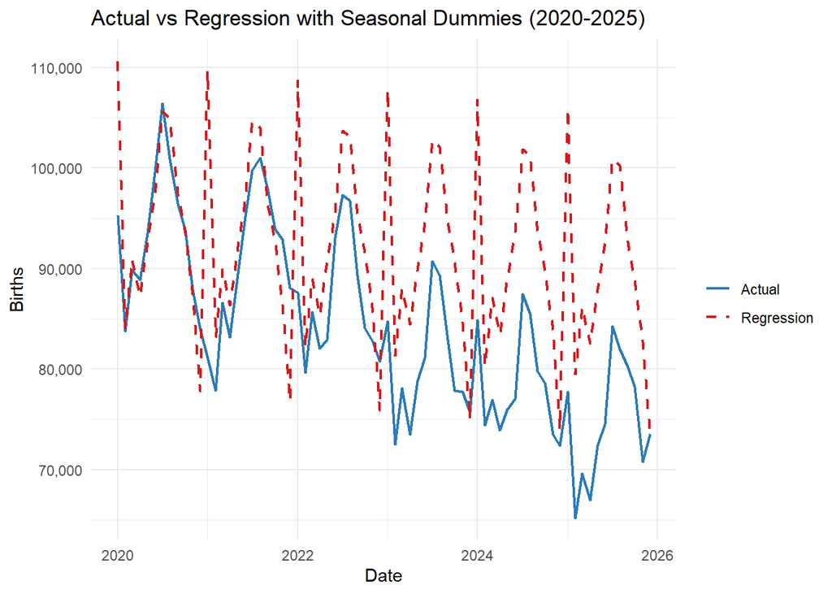

```r
ggplot(df_long %>% filter(date >= "2020-01-01"), aes(x = date)) +
  geom_line(aes(y = births,  color = "Actual"), linewidth = 0.8) +
  geom_line(aes(y = reg_fit, color = "Regression"), linewidth = 0.8, linetype = "dashed") +
  scale_color_manual(values = c("Actual" = "#2C7BB6", "Regression" = "#D7191C")) +
  labs(title = "Actual vs Regression with Seasonal Dummies (2020-2025)",
       x = "Date", y = "Births", color = "") +
  theme_minimal() + scale_y_continuous(labels = scales::comma)
```

```r
ggsave("outputs/figures/regression_seasonal_dummy_plot.png", width = 10, height = 5, dpi = 150)
```